# Activity: Structure your data

### Compare trends over time

Implement the structuring approach that you have identified in order to compare trends over time in the average valuation of companies that became unicorns in the year you selected above and in another year of your choice. Keep in mind the data type of the `Valuation` column and what the values in that column contain currently.

```python
# After identifying the additional year and time interval of interest, proceed with the following:
# Step 1. Filter by the additional year to create a subset that consists of companies that joined in that year.
companies_2020 = companies[companies['Date Joined'].dt.year == 2020]
companies_2021 = companies[companies['Date Joined'].dt.year == 2021]

# Step 2. Concatenate that new subset with the subset that you defined previously.
companies__2020_2021 = pd.concat([companies_2020, companies_2021], ignore_index=True)


# Step 3. As needed, add a column that contains the time interval that each data point belongs to,
#         in the concatenated DataFrame.
# Step 4. Transform the `Valuation` column as needed.
# Step 5. Group by the time interval.
#         Aggregate by computing average valuation of companies that joined per interval of the corresponding year.
#         Save the resulting DataFrame in a new variable.

companies_2020_2021["Quarter Joined"] = companies_2020_2021["Date Joined"].dt.to_period('Q').dt.strftime('%Y-Q%q')

companies_2020_2021["Valuation"] =  companies_2020_2021["Valuation"].str.strip("$B").astype(float)

companies_by_quarter_2020_2021 = companies_2020_2021.groupby(by="Quarter Joined")["Valuation"].mean().reset_index().rename(columns={"Valuation":"Average Valuation"})


# Display the first few rows of the new DataFrame to confirm that it was created.

print(companies_by_quarter_2020_2021.head(5))
```

```
  Quarter Joined  Average Valuation
0        2020-Q1           3.444444
1        2020-Q2           3.777778
2        2020-Q3           3.896552
3        2020-Q4           3.697674
4        2021-Q1           2.750000
```

## Step 3: Time-to-unicorn visualization

### Visualize the time it took companies to become unicorns

Using the `companies` dataset, create a box plot to visualize the distribution of how long it took companies to become unicorns, with respect to the month they joined.

```python
# Define a list that contains months in chronological order.
month_order = ["January", "February", "March", "April", "May", "June", "July",
              "August", "September", "October", "November", "December"]

# Print out the list to confirm it is correct.

month_order
```

```
['January',
 'February',
 'March',
 'April',
 'May',
 'June',
 'July',
 'August',
 'September',
 'October',
 'November',
 'December']
```

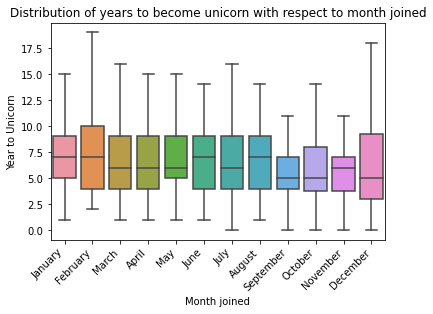

```python
# Create the box plot to visualize the distribution of how long it took companies to become unicorns, with respect to the month they joined.
# Make sure the x-axis goes in chronological order by month, using the list you defined previously.
# Plot the data from the `companies` DataFrame.

sns.boxplot(x=companies['Month joined'], y=companies['Year to Unicorn'],
           order=month_order, showfliers=False)

# Set the title of the plot.
plt.title('Distribution of years to become unicorn with respect to month joined')


# Rotate labels on the x-axis as a way to avoid overlap in the positions of the text.

plt.xticks(rotation=45, horizontalalignment='right')

# Display the plot.

plt.show()
```

**Question:** In the preceding box plot, what do you observe about the median value for `Years To Join` for each month?

## Step 4: Results and evaluation

### Visualize the time it took companies to reach unicorn status

In this section, you will evaluate the result of structuring the data, making observations, and gaining further insights about the data.

Using the `companies` dataset, create a bar plot to visualize the average number of years it took companies to reach unicorn status with respect to when they were founded.

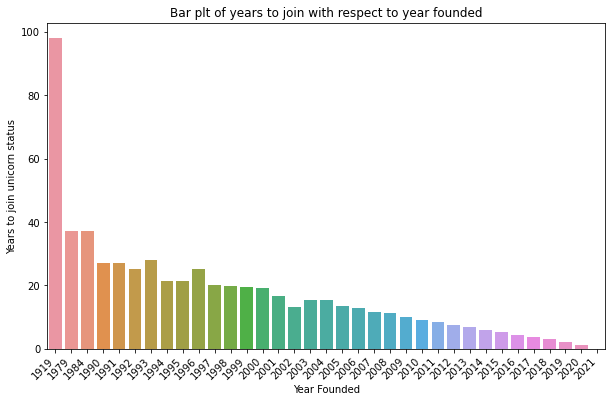

```python
# Set the size of the plot.

plt.figure(figsize=(10, 6))

# Create bar plot to visualize the average number of years it took companies to reach unicorn status
# with respect to when they were founded.
# Plot data from the `companies` DataFrame.

sns.barplot(x=companies["Year Founded"], y=companies["Year to Unicorn"], ci=False)

# Set title
plt.title("Bar plt of years to join with respect to year founded")

# Set x-axis label
plt.xlabel("Year Founded")

# Set y-axis label
plt.ylabel("Years to join unicorn status")

# Rotate the labels on the x-axis as a way to avoid overlap in the positions of the text.
plt.xticks(rotation=45, horizontalalignment ='right')


# Display the plot.
plt.show()
```

**Question:** What trends do you notice in the data? Specifically, consider companies that were founded later on. How long did it take those companies to reach unicorn status?

### Visualize the number of companies that joined per interval

Using the subset of companies joined in the year of interest, grouped by the time interval of your choice, create a bar plot to visualize the number of companies that joined per interval for that year.

```python
# Filter for companies that joined in 2021
companies_2021 = companies[companies['Date Joined'].dt.year == 2021]

# Extract the week number from the "Date Joined" column
companies_2021['Week Joined'] = companies_2021['Date Joined'].dt.isocalendar().week

# Group by the week and count the number of companies
companies_by_week_2021 = companies_2021.groupby('Week Joined').size().reset_index(name='Company Count')
```

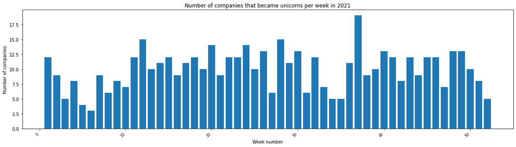

```python
# Set the size of the plot.
plt.figure(figsize=(20, 5))

# Create bar plot to visualize number of companies that joined per interval for the year of interest.
plt.bar(x=companies_by_week_2021['Week Joined'], height=companies_by_week_2021['Company Count'])
plt.plot()

# Set the x-axis label.
plt.xlabel("Week number")

# Set the y-axis label.
plt.ylabel("Number of companies")

# Set the title.
plt.title("Number of companies that became unicorns per week in 2021")

# Rotate labels on the x-axis as a way to avoid overlap in the positions of the text.
plt.xticks(rotation=45, horizontalalignment='right', fontsize=8)

# Display the plot.
plt.show()
```

**Question:** What do you observe from the bar plot of the number of companies that joined per interval for the year of 2021? When did the highest number of companies reach $1 billion valuation?

- Observations from a bar plot of the number of companies that became unicorns per week in 2021:
- The number of companies that joined unicorn status fluctuated over the weeks of 2021, with a trend of decline followed by an increase periodically.
- The highest number of companies reached $1 billion valuation in Week 37 of 2021, which corresponds to the third week of September 2021.
- The weeks in 2021 with the next highest number of companies becoming unicorns are Week 12 (which corresponds to the fourth week of March) and Week 28 (which corresponds to the third week of July).

### Visualize the average valuation over the quarters

Using the subset of companies that joined in the years of interest, create a grouped bar plot to visualize the average valuation over the quarters, with two bars for each time interval. There will be two bars for each time interval. This allows you to compare quarterly values between the two years.

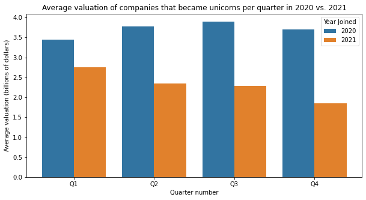

```python
# Using slicing, extract the year component and the time interval that you specified,
# and save them by adding two new columns into the subset.
companies_by_quarter_2020_2021['Quarter Number'] = companies_by_quarter_2020_2021['Quarter Joined'].str[-2:]
companies_by_quarter_2020_2021['Year Joined'] = companies_by_quarter_2020_2021['Quarter Joined'].str[:4]

# Set the size of the plot.
plt.figure(figsize = (10, 5))

# Create a grouped b plot
sns.barplot(x=companies_by_quarter_2020_2021['Quarter Number'],
           y=companies_by_quarter_2020_2021['Average Valuation'],
           hue=companies_by_quarter_2020_2021['Year Joined'])
plt.plot()

# Set the x-axis label.
plt.xlabel("Quarter number")

# Set the y-axis label.
plt.ylabel("Average valuation (billions of dollars)")

# Set the title.
plt.title("Average valuation of companies that became unicorns per quarter in 2020 vs. 2021")

# Display the plot.
plt.show()
```

**Question:** What do you observe from the preceding grouped bar plot?

- Observations from a grouped bar plot of average valuation of companies that became unicorns per quarter in 2020 vs. 2021:
- In each quarter, the average valuation of companies that joined unicorn status was higher in 2020 than in 2021.
- In 2020, Q3 was the quarter with the highest average valuation of companies that reached unicorn status, and there was a trend of increase from Q1 to Q2 and from Q2 to Q3.
- In 2021, Q1 was the quarter with the highest average valuation of companies that reached unicorn status, and there was a trend of decrease across the quarters.

**Question:** Is there any bias in the data that could potentially inform your analysis?

- Potential bias:
  - If there were bias in terms of which cities and countries were taken into account when collecting the data, then the analysis would be more representative of the cities and countries that are in the dataset than those that are not.
  - If the dataset did not include certain industries, then the analysis would be more representative of the industries that are included and may not reflect trends in those that are excluded from the data.
  - If the dataset had time gaps, (e.g, if companies that joined in certain windows of time were not included in the data), then that may have affected the patterns observed,depending on how salient the gaps were.
  - Another point of bias pertains to the nature of time data, there have been fewer years to collect data on companies that were founded more recently than for companies that were founded longer ago.

**Question:** What potential next steps could you take with your EDA?

- Potential next steps th EDA:

  ```
  * Analyze the data with respect to industries of unicorn companies at different datetime intervals.
  * Analyze the data with respect to cities or countries where unicorn companies were founded t differnet datetime intervals.
  * Clean the data as needed.
  ```

**Question:** Are there any unanswered questions you have about the data? If yes, what are they?

- Possible questions:
  - How many rounds of funding did each company require and when did this funding take place?
  - Have any of these unicorn companies acquired other companies along the way? If so, which companies acquired other companies, which companies did they acquire, and when did the acquisitions take place?

## Considerations

**What are some key takeaways that you learned from this lab?**

- Functions in the pandas library can be used for data manipulation in order to reorganize and structure the data.
- Converting strings that contain dates to determine format allow you to extract individual components from the data, such as month and year.
- Structuring the data in specific ways allows you to observe more trends and zoom in on parts of the data that are interesting to you.
- Functions in the matplotlib.pyplot module and the seaborn library can be used to create visualizations to gain further insight after structuring the data.

**What findings would you share with others?**

**What recommendations would you share with stakeholders based on these findings?**

**References**

Bhat, M.A. (2022, March).[*Unicorn Companies*](https://www.kaggle.com/datasets/mysarahmadbhat/unicorn-companies).

**Congratulations!** You've completed this lab. However, you may not notice a green check mark next to this item on Coursera's platform. Please continue your progress regardless of the check mark. Just click on the "save" icon at the top of this notebook to ensure your work has been logged.